# Digit Classification

Jonathan Eaton

2023-12-28

# Introduction

Computer vision is one of the hottest topics in machine learning. Training a computer to classify image data has massive implications, from document scanning to self-driving cars. Text recognition is a great introduction to the world of computer vision. In this analysis, I will use a random forest algorithm to classify handwritten digits. This can be a difficult task, because as any middle school teacher can tell you, deciphering handwriting is not always easy. Companies like Ancestry and FamilySearch frequently use text recognition algorithms to assist in digitally indexing historical records like census and immigration documents.

The dataset comes from Kaggle’s [Digit Recognizer competition](https://www.kaggle.com/competitions/digit-recognizer/data). Each digit is represented in its own row of data as a flattened 28 by 28 matrix of grayscale values (i.e., pixels). The first column of each dataset is the response variable (digit), and columns 2 through 785 are grayscale values ranging from 0 to 255. Values of 0 indicate white, and values of 255 indicate black, with grayscale integer values between.

As an initial exploration of the data, I took the training data subsets of all the zeroes, twos and sevens. For each of these subsets, I averaged the pixel grayscale values and convert these averages into 28 by 28 images. Thus, we can see what the “average” digit looks like from the handwriting sample.

Typically, I would perform data cleaning and a more robust inspection of the data. However, the data in this case has been previously cleaned.

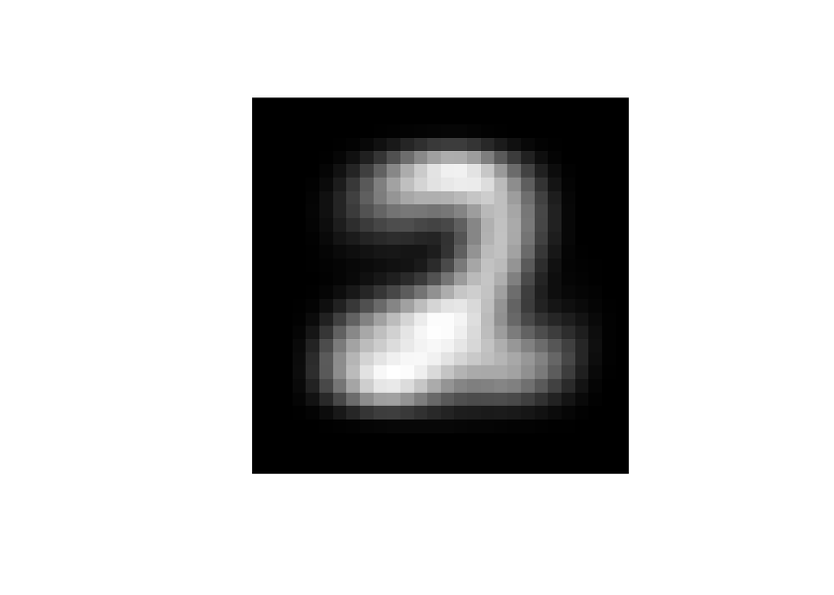

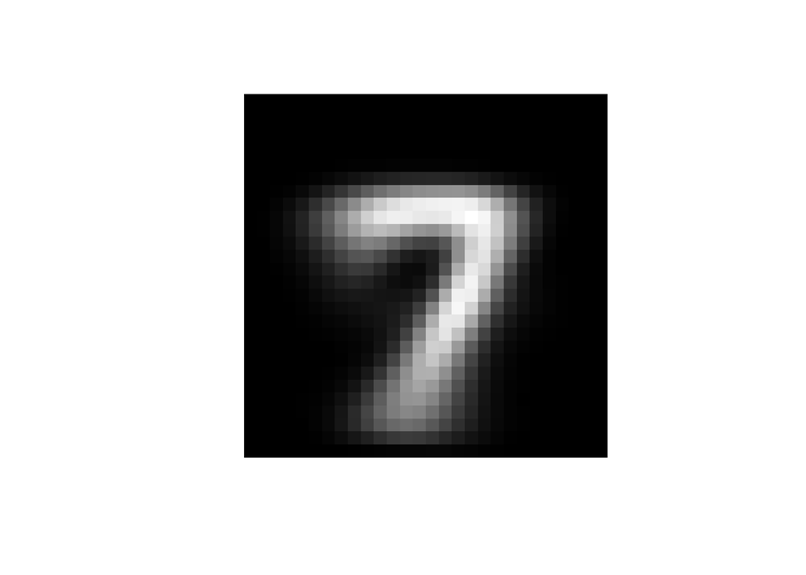

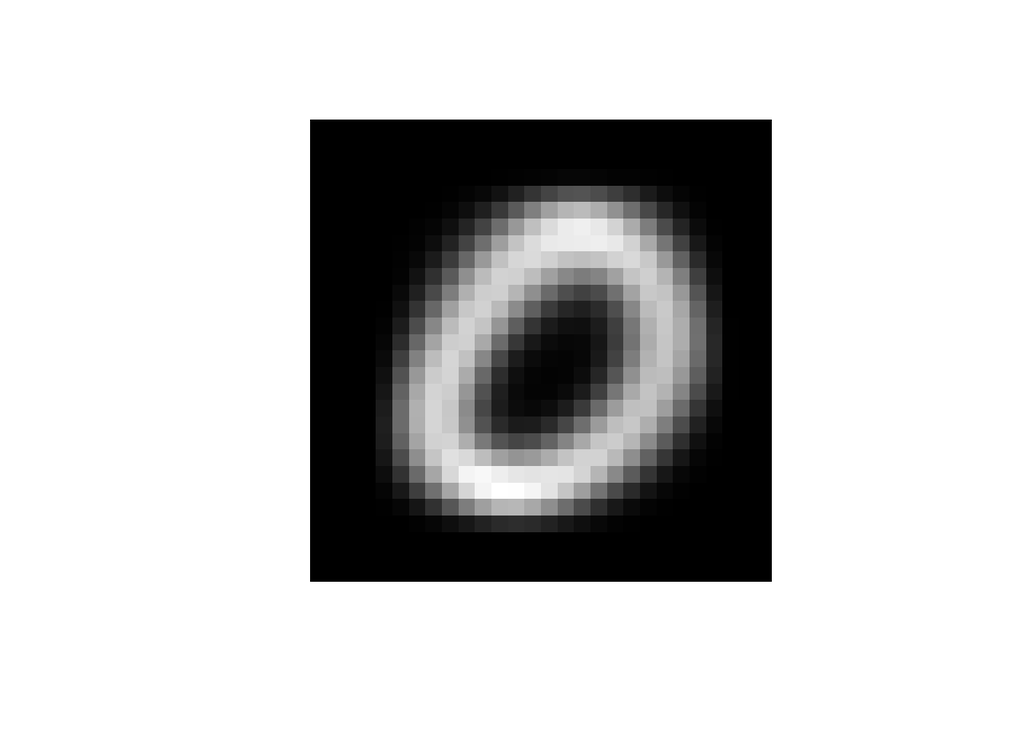

```r
digits2 <- digits[which(digits[,1]==2),]
digits7 <- digits[which(digits[,1]==7),]
digits0 <- digits[which(digits[,1]==0),]

#calculate example means for digits 0, 2 & 7
means2 <- data.frame(Column=1:784, Means=colMeans(digits2[,2:785]))
means7 <- data.frame(Column=1:784, Means=colMeans(digits7[,2:785]))
means0 <- data.frame(Column=1:784, Means=colMeans(digits0[,2:785]))

#display means as a 28x28 image
twos <- t(matrix(data.matrix(means2$Means), byrow=TRUE,28,28)[28:1,])
sevens <- t(matrix(data.matrix(means7$Means), byrow=TRUE,28,28)[28:1,])
zeroes <- t(matrix(data.matrix(means0$Means), byrow=TRUE,28,28)[28:1,])
```

# Methodology

I’ll use one of the simplest yet most effective classification algorithms, the random forest. To evaluate performance of the model and tune the hyperparameters, I randomly split the data from the training file into training and validation sets (80%-20% split). The parameters to be tuned are number of trees in the forest (50, 200, or 500), and the number of columns to utilize at each tree split ($\sqrt(p)$, i.e. 28, and $\frac{p}{10}$, i.e. 78, where $p$ is the total number of predictor columns in the dataset).

```r
set.seed(42)
val.ind <- sample(1:nrow(digits), size=floor(0.2*nrow(digits)))

digits.train <- digits[-val.ind,]
digits.val <- digits[val.ind,]

p <- 784
trees <- c(50,200,500)
ncols <- c(sqrt(p), round(p/10))
models <- NULL
accuracies <- NULL

for(n in trees) {
  for(m in ncols) {
    digits.rf <- randomForest(as.factor(label)~., data=digits.train,
                              ntree=n, mtry=m)
    pred.rf <- predict(digits.rf, digits.val[,-1])
    rf.accuracy <- mean(pred.rf != digits.val[,1])
    accuracies <- c(accuracies, rf.accuracy)
    models <- c(models, paste0("Trees: ",n,", mtry: ",m))
  }
}
```

# Results

The results of the 6 different models are compared in the chart below, with the misclassification rate displayed on the y axis. The model with the lowest misclassification rate was the model with 500 trees and 78 columns tried per split. Only 6 models could be compared due to computational and time limitations.

| trees | mtry | error |
| --- | --- | --- |
| 50 | 28 | 0.0410714 |
| 50 | 78 | 0.0383333 |
| 200 | 28 | 0.0369048 |
| 200 | 78 | 0.0379762 |
| 500 | 28 | 0.0371429 |
| 500 | 78 | 0.0365476 |

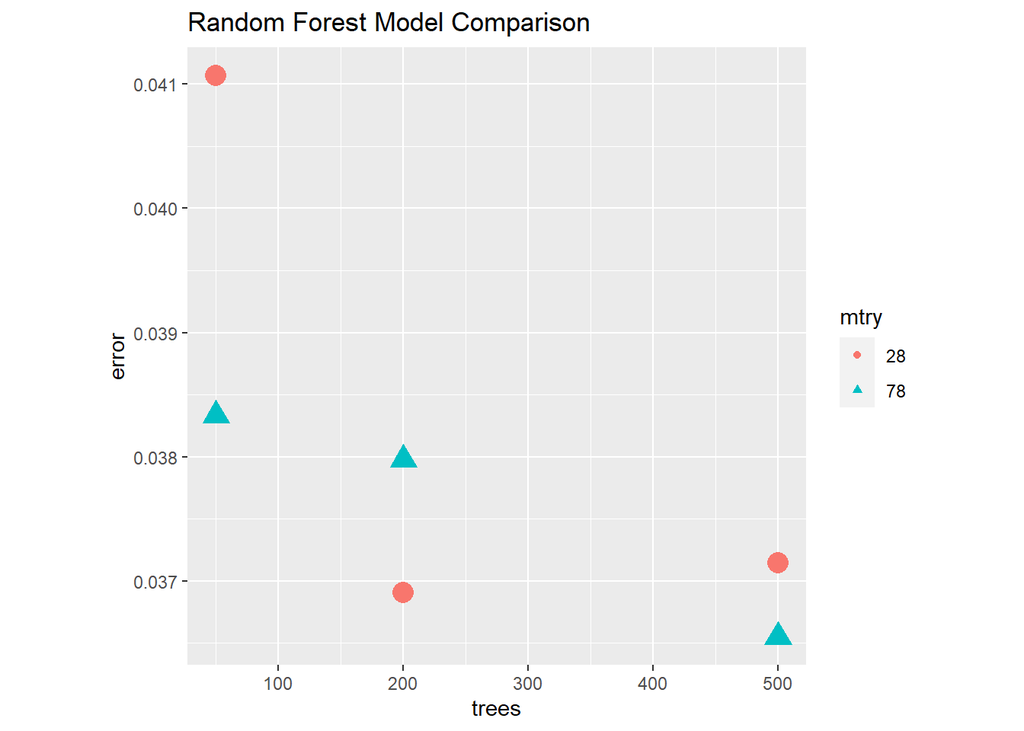

I then retrained this model using the entire training set to generate predictions for Kaggle’s test set of 28,000 digits. This resulted in a test accuracy rate of 0.96735. For future modifications to improve the accuracy of my predictions, I would consider testing other models like gradient boosting and neural networks.

This same process could be applied to broader handwriting recognition problems, like those faced by FamilySearch. Of course, their algorithms also need to recognize printed and cursive text in addition to numbers. However, with sufficiently large training data, a random forest classification model could likely identify the text with high accuracy.